[figure not shown]

# Predicting the Best Strategy to Win in Teamfight Tactics

Jason Dang, Nhat-Nguyen Vo, Wisely Kong

## Introduction

Teamfight Tactics (TFT) is an auto battler game developed by Riot Games. Auto battlers are strategy based games in which the player is given preparation time in order to assemble a team on a chess-like board (we'll just call these teams boards) with various units in order to fight an opposing player's board. These fights between boards do not receive any additional input from its players, as the units automatically move and attack until all units of a player's board is eliminated.

Since TFT is rather complex there are a variety of concepts within the game, but we will only cover the key mechanics in order to understand the tutorial. If you'd like a more in-depth explanation of the various mechanics of the game, they can be found [here.](https://mobalytics.gg/blog/tft-guide/)

In the game of TFT, there are 8 players per game, each starting off with 100 Health. Throughout the game, players will face off against other player's board. Losing a fight results in their health being deducted according to the amount of units remaining on the board and the duration of the game. At 0 Health, the player is eliminated.

The main objective in a game of TFT is to be among the last 4 players left alive, as the game considers "Top 4" to be a moral victory. But in order to truly win a game of TFT, a player must be the last player left alive. To recap:

- **Win** = Last Player alive, 1st place
- **Top 4** = 2nd, 3rd, 4th place. A moral victory, but a victory nonetheless
- **Bottom 4** = 5th, 6th, 7th, 8th place. A loss.

The main factors that go into a how a player's game will progress are: Gold, Level, Units, Augments, and Components/Items.

- **Gold**: During each preparation phase, the player is given Gold to utilize in order to make their board as strong as possible, such that either they outright win their next fight against an opponent or eliminate as many units as they possibly can before losing. Players can spend their Gold on either Levels or Units in order to achieve this.
- **Level**: The amount of units a player can place on their board is dependent on their current level. A player at level 3 can only place 3 units, level 4 can only place 4 units, and so on. The player naturally levels up as the game progresses but can also utilize their Gold during the preparation phase to level up faster. Being a higher level compared to an opponent means one more Unit on the board, increasing the likelihood of winning a fight.

[figure not shown]

- **Units**: During the preparation phase before facing against an opposing player's board, the player is presented a "Shop" with 5 Units in which they can utilize their Gold in order to purchase and then place on their board for the next fight. The player can also choose to use their Gold instead to re-roll the Shop to choose from another 5 random choices. Units have three important aspects that affects their usefulness: Traits and Cost.
  - *Traits*: Units have "Traits" that grant special effects for Units with the Trait, but these effects can only be activated when a certain number (this number varies per Trait) of unique Units with the Trait are placed on the board at the same time. The more Units there are of the same trait, the stronger the effect.

[figure not shown]

  - *Cost*: When Units appear in the Shop, they cost a certain amount of Gold to purchase. The amount a Unit costs relates to how powerful the Unit is, where a Unit costing 1 Gold (the lowest amount) is comparatively weaker to a Unit costing 5 Gold (the highest amount). In addition, the Cost of a Unit relates to how often they would appear in a Shop, in accordance to the player's Level. Lower cost units (1 Gold, 2 Gold, and 3 Gold) appear more at Levels 1, 2, 3, and 4 but less so at higher Levels 7, 8, and 9. Vice versa for higher cost units (4 Gold, 5 Gold)

[figure not shown]

- **Augments**: In certain intervals of the game, all players are presented with 3 options that provides a variety of benefits to the player. There are 3 Tiers of Augments, rising from lowest strength to highest strength: Silver, Gold, and Prismatic. When being presented with the 3 options, all options are of the same tier for all the players. Players can only have a total of 3 Augments per game and cannot receive duplicate augments.

[figure not shown]

- **Components/Items**: In certain intervals of the game, players are granted materials, also known as Components, in which they can place on their Units to make them negligibly stronger. When two Components are combined (by placing both onto a unit), an Item is created based on the combined components that grants special effects for that specific Unit, making them significantly stronger. A Unit can only have a maximum combination of 3 Items/Components and cannot be interchanged once placed. Ideally, the most important Units on a player's board will always receive 3 Items.
  - There are also Items that are uncraftable via components and must be obtained through other means (i.e. Augments).

[figure not shown]

More specific information on units, augments, items, etc can be found [here](https://tftactics.gg/).

In this tutorial we will learn how to extract data from an API, clean the extracted data to be usable for analysis, how to interpret patterns from the data gathered, and how to use a decision tree in the context of TFT. By the end, we should have a general idea of what strategies/choices contributes to a player in order to place top 4 or (more importantly) win in a game of TFT. By making this tutorial, we hope to grant new and experienced players alike a strategy that'll help them improve the decisions they make in game.

## Data Collection

In order to predict the best strategy in order to win in TFT, we must first decide where we will be retrieving our data. We decided the best source of data would come from the best players in the game, as they are considered the best for a reason: they know how to win. In TFT, the top players at a given time can be located through [this link, showing the leaderboard for the top players in North America](https://lolchess.gg/leaderboards?mode=ranked&region=na). As for the contents of the data, we arbitrarily chose to select the top 100 players and their last 75 games played. Since the leaderboard is constantly changing every few minutes, as players move up and down the leaderboard, we uploaded a compiled dataset & any necessary dictionaries to [Kaggle](https://www.kaggle.com/datasets/cmsc320tftproject/cmsc320-tft-challenger-dataset-set-65) to ease the replication process of this tutorial and to have your data be consistent with what we use. But for clarity sakes, we will showcase the data scraping and cleaning process.

## Libraries

For this tutorial, we will be using several Python 3 libaries in order to accomplish our goal. For more information on these libaries, their documentation are linked here:

- [Requests](https://docs.python-requests.org/en/latest/)
- [CSV](https://docs.python.org/3/library/csv.html)
- [BeautifulSoup](https://www.crummy.com/software/BeautifulSoup/bs4/doc/)
- [json](https://docs.python.org/3/library/json.html)
- [Pandas](https://pandas.pydata.org/pandas-docs/stable/)
- [Numpy](https://numpy.org/doc/stable/user/)
- [Seaborn](https://seaborn.pydata.org/)
- [Matplotlib](https://matplotlib.org/stable/users/index)
- [AST](https://docs.python.org/3/library/ast.html)
- [Sklearn](https://scikit-learn.org/stable/user_guide.html)
- [Warning](https://docs.python.org/3/library/warnings.html)

```python
# Import the necessary libraries that will be used for the tutorial
import requests
import csv
from bs4 import BeautifulSoup
import json
import pandas as pd
import numpy as np
import seaborn as sns
import matplotlib.pyplot as plt
from ast import literal_eval
from sklearn import tree, neighbors
from sklearn.linear_model import LinearRegression
from sklearn.model_selection import train_test_split
import warnings

# ignore unnecessary warnings from showing up in output
warnings.filterwarnings('ignore')
```

The first step in the Data Collection process is gathering the names of those within the Top 100 rankings, based on the leaderboard website. To do this, we are obtaining the raw HTML of the leaderboard website and explicitly looking the names that are listed.

**New functions used:**

- requests.get(url): Gain access to the given url for manipulation
- BeautifulSoup(url.content, "html.parser"): Parses the url into a text format so we can find specific elements
- soup.find(): Search for an element in a given text format, returns the first one found
- table_body.find_all(): Similar to find() but instead returns a list of all elements found
- text.strip(): Method to remove all spaces from a string
- list.append(): Adds an element to a list
- array[].partition(separator): Splits a string at a specified point into a tuple. We do this to remove any unnecessary information
- array.lstrip(): Removes spaces to the left of the specified string

```python
# Obtain the HTML for the leaderboard website in order to selectively obtain the names of
# those in the Top 100.
leaderboard = requests.get("https://lolchess.gg/leaderboards?mode=ranked&region=na")
# Using the library BeautifulSoup, parse the HTML to obtain the required information easier
# (the names of the Top 100)
soup = BeautifulSoup(leaderboard.content, 'html.parser')

# Create an array in order to hold the names
playerList = []

# Limit the HTML to show just the relevant sections (the names)
table_body=soup.find('tbody')
rows = table_body.find_all('tr')

# Iterate through the HTML and store specifically the names of the player into the array.
for row in rows:
    cols=row.find_all('td')
    cols=[x.text.strip() for x in cols]
    # Separate irrelevant text from the player's name with .partition()
    playerList.append(cols[1].partition("\n\n"))

# Need to remove the irrelevant text that resulted from the previous .partition() call
cleanList = []
for currentPlayer in playerList:
    player = (currentPlayer[2].lstrip())
    cleanList.append(player);
```

The next step is to utilize the Riot Games API in order to extract the necessary data, that being the most recent 75 games those 100 players have played. In order to access the Riot Games API, you must [create / login](https://developer.riotgames.com/) to a Riot Games account to generate a development API key. Again, downloading the dataset from Kaggle will allow you to avoid having to deal with creating a development API key.

**New Functions Used**

- json.load(filepath): Opens a json file at filepath and returns it as a dictionary

```python
# This is the API Key required to utilize Riot Games API. These expire 24 hours after being
# generated, so this will need to be updated if you want to progress with the code.
key = "RGAPI-792fade4-60a0-4bc5-968d-2cacf97fe150"
# Each player has a unique ID that is recognized by the Riot Games API. With this ID, we can now utilize the API to obtain the last 75 matches of that particular ID.
puuidList = []

# Iterate through the player's name in order to obtain their PUUID.
for player in cleanList:
    url = "https://na1.api.riotgames.com/tft/summoner/v1/summoners/by-name/" + player + "?api_key=" + key
    r = requests.get(url)
    soup = BeautifulSoup(r.content, 'html.parser')
    jsonConvert = json.loads(str(soup))

    try:
        puuid = jsonConvert['puuid']
        puuidList.append(puuid)
    except KeyError:
        # Calling the API with too many commands could result in a Rate Limit Exceeded Error, which might result in losing data for that specific player.
        # If experiencing the Rate Limit Exceeded Error, wait to run the code again.
        print("Unable to get " + player + " data")
```

```python
# Use a dictionary to store the last 75 matches per player.
matches = {}

for current in puuidList:
    url = "https://americas.api.riotgames.com/tft/match/v1/matches/by-puuid/" + current + "/ids?count=75&api_key=" + key
    r = requests.get(url)
    soup = BeautifulSoup(r.content, 'html.parser')
    jsonConvert = json.loads(str(soup))
    matches[current] = jsonConvert

listToSet = []

#Take the dictionary and convert to a list. Then convert that to a set to create a unique list of
# matches for the dataset, to remove any duplicate matches
for puuid in matches:
    currentMatchList = matches[puuid]
    for currentMatch in currentMatchList:
        listToSet.append(currentMatch)

listToSet = list(set(listToSet))
```

Once the names are gathered and an API Key is obtained, the final step would be to compile and tidy the relevant data into a table.

**New Functions Used**

- pd.DataFrame(): Creates a two-dimensional table to store data
- soup.replace(str1, str2): Replaces any occurence of str1 with str2
- pd.DataFrame.from_dict(dict): Returns a pandas dataframe created using data form dictionary dict
- df.drop(): deletes a column(s) or row(s) from dataframe df
  - axis tells the function whether to delete a row or a column
  - columns specifies which column to delete
  - inplace tells the function whether to return a new dataframe or to apply the function to the existing dataframe
- pd.concat([dataframe1, dataframe2], axis = 0): Combines dataframes along a specific axis (row or column).
- pd.read_csv(): Reads a CSV into a dataframe

**Side Note:**

- Utilizing a large amount of requests.get() on the Riot API website will result in a Error 429 Rate Limit Exceeded, resulting in not being able to get all of the data needed. To avoid this, either avoid calling a large amount of requests.get() at once or [download the dataset here](https://www.kaggle.com/datasets/cmsc320tftproject/cmsc320-tft-challenger-dataset-set-65)

```python
# Create the empty dataframe for the data, that will display the relevant information from a match
df = pd.DataFrame();

# Since the Riot API limits the amount of requests you can send, you'd have to change the range of
# the for loop in order to extract all of the matches (i.e. change the [0:10] to a different
# range of values like [10:20]). This process does take a bit of time, mostly due to waiting
# for the ability to  send more requests The rest of the tutorial will use the
# aforementioned CSV file from the Kaggle link in order to have consistent data.

for match in listToSet[0:10]:
    url = "https://americas.api.riotgames.com/tft/match/v1/matches/" + match + "?api_key=" + key
    r = requests.get(url)
    soup = BeautifulSoup(r.content, 'html.parser')
    soup = str(soup)
    soup = soup.replace("\">\"", "")
    soup = soup.replace("</releases>", "")
    jsonConvert = json.loads(str(soup))
    data = pd.DataFrame.from_dict(jsonConvert['info']['participants'])
    # These dropped columns are irrelevant to the tutorial as they cannot be used to determine
    # how a player placed 1st/top 4/bottom 4
    data = data.drop('companion', axis = 1)
    data = data.drop('gold_left', axis = 1)
    data = data.drop('last_round', axis = 1)
    data = data.drop('players_eliminated', axis = 1)
    data = data.drop('time_eliminated', axis = 1)
    data = data.drop('puuid', axis = 1)
    data = data.drop('total_damage_to_players', axis = 1)
    data['Match ID'] = jsonConvert['metadata']['match_id']
    df = pd.concat([df, data], axis = 0)
```

```python
# The dataset from the CSV, that shows the results and relevant data of all of the matches
# Can be found in the Kaggle link
tutorialDataset = pd.read_csv('./data/TFTdataset.csv')
tutorialDataset
```

|  | augments | level | placement | traits | units | Match ID |
| --- | --- | --- | --- | --- | --- | --- |
| 0 | ['DebonairTrait', 'Distancing2', 'DebonairEmbl... | 7 | 8 | [{'name': 'Assassin', 'num_units': 2, 'style':... | [{'character_id': 'Talon', 'items': [69, 19, 2... | NA1_4247681350 |
| 1 | ['AssassinCutthroat', 'RichGetRicher', 'Divers... | 9 | 3 | [{'name': 'Arcanist', 'num_units': 2, 'style':... | [{'character_id': 'Kassadin', 'items': [], 'na... | NA1_4247681350 |
| 2 | ['EnchanterTrait', 'SunfireBoard', 'TwinshotTr... | 8 | 2 | [{'name': 'Bruiser', 'num_units': 2, 'style': ... | [{'character_id': 'Sejuani', 'items': [], 'nam... | NA1_4247681350 |
| 3 | ['CalculatedLoss', 'ExperimentalEmblem', 'Arca... | 9 | 1 | [{'name': 'Arcanist', 'num_units': 4, 'style':... | [{'character_id': 'Kassadin', 'items': [], 'na... | NA1_4247681350 |
| 4 | ['Phalanx1', 'ArcanistSpellBlade', 'Experiment... | 9 | 4 | [{'name': 'Arcanist', 'num_units': 2, 'style':... | [{'character_id': 'RekSai', 'items': [], 'name... | NA1_4247681350 |
| ... | ... | ... | ... | ... | ... | ... |
| 39995 | ['Disintegrator1', 'TomeOfTraits1', 'AssassinE... | 9 | 1 | [{'name': 'Assassin', 'num_units': 4, 'style':... | [{'character_id': 'Zilean', 'items': [], 'name... | NA1_4255593521 |
| 39996 | ['SocialiteDuet', 'Disintegrator1', 'Backfoot2'] | 8 | 3 | [{'name': 'Bodyguard', 'num_units': 1, 'style'... | [{'character_id': 'Corki', 'items': [], 'name'... | NA1_4255593521 |
| 39997 | ['ItemGrabBag1', 'ThrillOfTheHunt1', 'JeweledL... | 8 | 4 | [{'name': 'Assassin', 'num_units': 4, 'style':... | [{'character_id': 'Nocturne', 'items': [], 'na... | NA1_4255593521 |
| 39998 | ['Featherweights1', 'Weakspot', 'Archangel2'] | 8 | 7 | [{'name': 'Arcanist', 'num_units': 2, 'style':... | [{'character_id': 'Poppy', 'items': [], 'name'... | NA1_4255593521 |
| 39999 | ['Underdogs', 'ScholarTrait', 'BinaryAirdrop'] | 8 | 8 | [{'name': 'Arcanist', 'num_units': 1, 'style':... | [{'character_id': 'Kassadin', 'items': [66, 1,... | NA1_4255593521 |

40000 rows × 6 columns

Within the compiled CSV/dataset, each row represents a player. The columns are:

- Augments: The three augments the player ended a game with
- Level: The level the player ended a game with
- Placement: The player's overall placement at the end of the game
- Traits: The active Traits the player had by the end of the game
- Units: The Units the player had by the end of the game (with their rarities and items)
- Match ID: The ID of the game.

# Data Management

With the csv file created we can now clean it to make the dataset more readable.

As of now each row of the csv will look something like this:

```
"augments": "['TFT6_Augment_DebonairTrait', ...]",

"level": "8",

"placement": "8",

"traits": "[{'name': 'Set6_traitname', 'num_units': 1, 'style': 0, 'tier_current': 0, 'tier_total': 4}, ...]",

"units": "[{'character_id': 'TFT6_(CharacterName))', 'itemNames': ['TFT_Item_(ItemName)', ...], 'items': [(ItemID), ...], 'name': '(CharacterName)', 'rarity': (Rarity number), 'tier': (Unit Cost))}, ...]",

"Match ID": "Match ID"
```

Of the information available there's alot of redundant and useless headers such as "TFT6_" and "Set6_" or "TFT_Item_". For the sake of readability we shall remove them from the csv.

To do so we can create a function that finds these exact phrases in the csv and simply erases them.

**New functions used:**

- open(filepath): Opens the file located at filepath for editing/reading and returns an open file variable
  - optional second variable gives permissions such as read-only, write-only or both where 'w' gives write permissions
- f.read(): reads the contents of file f and returns it as a string
- f.close(): Closes the open file f to avoid accidentally editing it when we don't want to
- str1.replace(str2, str3): Searches str1 for instances of str2 and replaces them with str3 and returns the resulting string.
- f.write(text): write text to an open file f

```python
# var filePath: str, contains the filepath that leads to the csv file
def cleanCSV(filePath):
    # open the csv file
    f = open(filePath)
    # save text in the file to a string to edit
    text = f.read()
    #  close the csv file
    f.close()

    # the next 6 lines of code deletes the specific unnecesary phrases
    # as well as an error item id that sometimes appears in collected data from our csv
    text = text.replace('TFT6_', '')
    text = text.replace('TFT6b_', '')
    text = text.replace('Set6_', '')
    text = text.replace('TFT_Item_', '')
    text = text.replace('Augment_', '')
    text = text.replace(', 10006', '')

    # open the csv file again
    f = open(filePath,'w')

    # save new clean text to the csv file
    f.write(text)

    # close the csv file
    f.close()

# run the function which will overwrite the old dataset with the cleaned dataset
cleanCSV("./data/TFTdataset.csv")
```

The CSV is now cleaned of useless headers. We will now convert the csv to a JSON to make the data set easier to work with as well as give each row a unique ID.

Once again we'll make a function for this as well

**New functions used:**

- csv.DictReader(filepath): Reads the contents of csv file at filepath as a list of dictionary objects
- json.dumps(dict): Returns a json formatted dictionary
  - optional indent parameter makes the printed json look better

```python
# var csvFilePath: str, contains the filepath that leads to the csv file
# var jsonFilePath: str, place to save the JSON file
def make_json(csvFilePath, jsonFilePath):

    # create a dictionary called data
    data = {}
    # create a counter to number each row of the csv
    counter = 0
    # Open the csv with a csv reader called DictReader
    with open(csvFilePath, encoding='utf-8') as csvf:
        csvReader = csv.DictReader(csvf)

        # Convert each row into a dictionary and add it to data
        for rows in csvReader:

            # save the row to the key represented by the counter
            data[counter] = rows
            # increment the counter
            counter += 1

    # Open a json writer, and use the json.dumps() function to convert the dictionary into a Json object
    # save the JSON object to a file using write()
    with open(jsonFilePath, 'w', encoding='utf-8') as jsonf:
        jsonf.write(json.dumps(data, indent=4))

# run the function which will create a json file version of the csv file
make_json("./data/TFTdataset.csv", './data/TFTdataset.json')

#  open the json file and save it to a variable for use later using json.load()
with open('./data/TFTdataset.json') as json_file:
    data = json.load(json_file)
```

We will now convert all the item IDs into the English names of the Items to make the data easier to read, to do so we will be needing one more thing and thats a itemDictionary or a dictionary for converting item IDs to items names.

These can be found by searching through the en_us.json file found at https://raw.communitydragon.org/latest/cdragon/tft/

You can either manually skim through the file for item codes or create a code to clean this, however for simplicity's sake the finished item dictionary is already saved to a json file and included within the Kaggle link.

```python
with open('./data/TFTitemDictionary.json') as json_file:
    itemDictionary = json.load(json_file)
```

With a JSON file and an item dictionary, we can now replace all item ID numbers with Item Names as well as remove redundant sections such as "itemName" and "name".

**New functions used:**

- list(var): Returns var converted into a list
- dict.key(): returns a list of keys contained within the dictionary dict
- len(var): returns the length of var where var is usually a string or list
- literal_eval(str): takes a string and converts it into the type that the string represents
  - example: "[1, 2, 3, 4, 5]" would become [1, 2, 3, 4, 5]
- range(i): returns a list containing all numbers up to integer i
- dict.pop(k): deletes a the key k from a dictionary dict along with what the key represented

```python
# create a list containing the all row numbers (keys) of the dataset
keys = list(data.keys())

# iterate through the list of keys
for key in keys:
    # save the units section of the row specified by key
    units = data[key]['units']

    # Units will be in the form of a list of dictionaries representing each unit in the team within a string
    # We want string to be just a list
    # To do so we will first make sure that units is a string

    if(units.__class__.__name__ == 'str'):
        if len(units) < 2:
            print("error line: ", key)
        # convert the string into a list of dictionaries using literal_eval()
        units = literal_eval(units)

    # For every item in every unit within the row we replace each ID with its respective name within the itemDictionary
    for char in range(len(units)):
        info = list(units[char].keys())
        # if this unit has a "itemNames" section remove it
        if 'itemNames' in info:
            units[char].pop('itemNames')

        # if this unit has a "names" section remove it
        if 'names' in info:
            units[char].pop('name')
        for item in range(len(units[char]['items'])):

            # Confirm that the ID is an actual Item ID by making sure its length is less or equal to 4
            # This is for the case that the item name is already there which could be the case
            if(len(str(units[char]['items'][item])) <= 4):
                units[char]['items'][item] = itemDictionary[str(units[char]['items'][item])]

    # update the row with the new information
    data[key]['units'] = units

# Save the dictionary to the json file
with open('./data/TFTdataset.json', 'w') as json_file:
    json.dump(data, json_file)
```

We can now convert the json directly into a pandas dataframe for analysis.

**New functions used:**

- l.apply(f): Applies func f on every item of list l and returns the result
- pd.to_numeric(l): Converts all values in list l into integers
  - example: ["1", "2", "3", "4", "5"] becomes [1, 2, 3, 4, 5]

```python
# if the JSON isn't already saved to a variable in the form of a dictionary
# you will first need to open the json file which can be done with the following 2 lines of
# commented code

# with open('TFTdataset.json') as json_file:
#     data = json.load(json_file)

df = pd.DataFrame.from_dict(data, orient = 'index')

# Some columns are currently occupied by arrays in the form of strings instead of just arrays
# To fix this you can use the following code that simply runs eval() on each array string and turns them into regular arrays
df["augments"] = df["augments"].apply(eval)
df["traits"] = df["traits"].apply(eval)
df["placement"] = pd.to_numeric(df["placement"])

# Remove extraneous columns like Match ID and level.
df.drop(axis=1, columns=['Match ID', 'level'], inplace=True)
```

# Exploratory Data Analysis

In this section, we will be going in-depth into the cleaned data and visualizing statistical aspects of TFT mechanics particuarly: Units, Traits, Augments, and Items. But first, we have to import a few related dictionaries, as the Riot API does a poor job of providing all information needed and keeping the names consistent between the game and the API.

```python
# Dictionary to determine what Tier an Augment is
with open('./data/TFTAugmentDictionary.json') as json_file:
    augmentDictionary = json.load(json_file)

# Dictionary to fix the names of Augments, so they are consistent with the in-game name
with open('./data/TFTAugmentNamesDict.json') as json_file:
    augmentNamesDictionary = json.load(json_file)

# Dictionary to fix the names of Traits, so they are consistent with the in-game name and make more sense
with open('./data/TFTTraitDictionary.json') as json_file:
    traitDictionary = json.load(json_file)
```

First, we'll create a function that will calculate the win rate, top 4 rate, and bottom 4 rate for the given data. A funtion was created to achieve these tasks because it will help simplify and eliminate the need to duplicate code.

Input:

- data (DataFrame): The target dataframe for calculating the win rate for
- group (String): The group that the data should be grouped by
- aggregate_funcs (Dictionary): A dictionary that maps a specific column to a specific aggregate function

Output: Pandas DataFrame

**New functions used:**

- numpy.where(): Return an element a or b depending on the condition provided
- df.groupby(): Groups rows together by the specified column value
- df.aggregate(): Combines dataframe values based on a specified aggregate function
- df.insert(): Inserts a column into the DataFrame at the specified location

```python
def data_vs_rate(data, group, aggregate_funcs):
    # A placement of 1 equates to a win
    data["wins"] = np.where(data["placement"] == 1, 1, 0)

    # A placement of 2,3,4 equates to a "Top 4"
    data["top_4"] = np.where((data["placement"] > 1) & (data["placement"] <= 4), 1, 0)

    # A placement of 5, 6, 7, or 8 equates to a loss/"Bottom 4"
    data["losses"] = np.where(5 <= data["placement"], 1, 0)

    # Temp variable to keep track of all games, which can then be used by
    # an aggregate function to count all games
    data["games"] = 1

    # Group the data by the targeted group and aggregate the specific column
    # using specified aggregate functions (i.e sum(), count(), etc.)
    data = data.groupby([group]).aggregate(aggregate_funcs)

    # Create the bottom 4 rate column
    data.insert(0, 'bot4_rate', data["losses"] / data["games"])

    # Create the top 4 rate column
    data.insert(0, 'top4_rate', data["top_4"] / data["games"])

    # Win rate is calculated by the number of wins / total number of games
    # Create the win rate column
    data.insert(0, 'winrate', data["wins"] / data["games"])

    return data
```

Then, create a function to weigh the variables winrate.

This is needed because a simple formula like (# of wins)/(# of games) would hold bias towards variables that appeared in less games, hence we must weigh variables by taking in their # of games in comparison to the number of games that the other variables appear in. To do this we simply add the average # of wins that all variables have to each variable and divide it by the average number of games that all variables appear in plus the variables own number of games giving us a weighted winrate.

Input:

- data (DataFrame): The target dataframe to calculate the weighted win rate for
- category (String): The specified rate (win rate, top 4 rate, bot 4 rate) to weight Output: A Pandas Series

**New functions used:**

- df.mean(): Calculates the mean of the column (series) values

```python
def get_weighted_rate(data, category):
    numer = data[category] + data[category].mean()
    denom = data['games'] + data["games"].mean()
    return numer / denom
```

Function that creates the weighted rate columns (win, top 4, and bottom 4) and adds it to the provided dataframe.

Input:

- data (DataFrame): The target dataframe to calculate the weighted win rate for

Output: A Pandas DataFrame

```python
def add_weighted_rate(data):
    data.insert(0, 'weighted_bot4', get_weighted_rate(data, 'losses'))
    data.insert(0, 'weighted_top4', get_weighted_rate(data, 'top_4'))
    # Generate the weighted win rate for augments.
    data.insert(0, 'weighted_winrate', get_weighted_rate(data, 'wins'))

    return data
```

Each player ends a TFT match with a number of augments. These augments are stored as an array in the row of a specific player. To speed up the process of grouping each augment with their specific win rate, we need to separate the augments of each player into their own separate columns in the dataframe using **explode()**. We can then proceed with using **map()** to map each augment to their respective tier and in-game name.

We need to then generate the unweighted win rate for each augment. This functionality is provided by our **data_vs_rate()** function using designated aggregate functions for each column of interest (wins, losses, games, tier). We can then use the unweighted rates to generate the weighted rates using our **add_weighted_rate()** function.

To assist with plotting, we decided the index of each augment which contained the name of the column should be placed into their own column in the dataframe. It's because on the FacetGrid() function, the index column of a DataFrame is not hashable. To get the highest win rate at the top, we sorted the weighted win rate by descending order.

**New functions used:**

- df.explode(): Splits the array values into their own separate rows in the dataframe
- df[].map(): Subsitute each value in the series with another value using a dictionary
- data_vs_rate(): Takes in a dataframe, string, and dictionary as input to generate a unweighted win rate column
- add_weighted_rate(): Takes in dataframe and string as input to return a series with the rates weighted by the number of games
- df.index(): Returns the index of a dataframe
- df.sort_values(): Sort the values in the specified column by the specified order

```python
# Split the array of augments into different rows in the dataframe
augment_df = df.explode("augments")

# Each augment has a specific tier (Silver, Gold, Prismatic). We manually mapped the augment to their
# respective tier in a JSON file and turned it into a dictionary that we can use to populate the tiers
# in the dataframe.
augment_df['tier'] = augment_df['augments'].map(augmentDictionary)


# Some of the augment names labeled inside the Riot Games API is inaccurate compared to the names in the game.augment_df
# Similarly, we mapped the augment's name to the correct name and turned it into a dictionary for accuracy
augment_df['augments'] = augment_df['augments'].map(augmentNamesDictionary)

# Map specific columns to their designated aggregate function. We need the total number of
# wins, top 4, losses, games, and have each tier mapped to the correct augment.
aug_aggregate_funcs = {'wins': 'sum', 'top_4': 'sum', 'losses': 'sum', 'games': 'count', 'tier':pd.Series.mode}

# Generate the unweighted rates for the augments with the function we previously defined.
augment_df = data_vs_rate(augment_df, 'augments', aug_aggregate_funcs)

# Generate the weighted rates for the augments with the function we previously defined.
augment_df = add_weighted_rate(augment_df)

# Place the names for all augments in their own column to help with plotting.
augment_df.insert(0, 'augment', augment_df.index)

# To organize the data, we decided to place the names of the augments in the front and the names of the
# tiers after the augment names
augment_df.insert(1, 'tier', augment_df.pop('tier'))

# Sort the weighted win rates in descending order to get the highest win rate at the top and the lowest
# win rate at the bottom.
augment_df = augment_df.sort_values('weighted_winrate', ascending=False)

# Display the dataframe
augment_df
```

| augments | augment | tier | weighted_winrate | weighted_top4 | weighted_bot4 | winrate | top4_rate | bot4_rate | wins | top_4 | losses | games |
| --- | --- | --- | --- | --- | --- | --- | --- | --- | --- | --- | --- | --- |
| Double Trouble 2 | Double Trouble 2 | Gold | 0.180209 | 0.366725 | 0.453066 | 0.239686 | 0.353635 | 0.406680 | 122 | 180 | 207 | 509 |
| The Golden Egg | The Golden Egg | Prismatic | 0.168300 | 0.363562 | 0.468138 | 0.264228 | 0.329268 | 0.406504 | 65 | 81 | 100 | 246 |
| Binary Airdrop | Binary Airdrop | Gold | 0.162526 | 0.379475 | 0.457998 | 0.176511 | 0.379808 | 0.443681 | 257 | 553 | 646 | 1456 |
| Sharpshooter | Sharpshooter | Prismatic | 0.157498 | 0.388629 | 0.453873 | 0.197279 | 0.401361 | 0.401361 | 87 | 177 | 177 | 441 |
| Cybernetic Uplink 2 | Cybernetic Uplink 2 | Gold | 0.155163 | 0.371055 | 0.473782 | 0.170639 | 0.367016 | 0.462345 | 179 | 385 | 485 | 1049 |
| ... | ... | ... | ... | ... | ... | ... | ... | ... | ... | ... | ... | ... |
| Blue Battery 1 | Blue Battery 1 | Silver | 0.105745 | 0.369511 | 0.524744 | 0.099135 | 0.366571 | 0.534294 | 172 | 636 | 927 | 1735 |
| Ascension | Ascension | Silver | 0.105469 | 0.354766 | 0.539765 | 0.089261 | 0.336123 | 0.574616 | 64 | 241 | 412 | 717 |
| Ludens Echo 2 | Ludens Echo 2 | Gold | 0.104120 | 0.386213 | 0.509667 | 0.094457 | 0.389539 | 0.516003 | 121 | 499 | 661 | 1281 |
| Tiny Titans | Tiny Titans | Silver | 0.101791 | 0.431310 | 0.466898 | 0.089431 | 0.457995 | 0.452575 | 99 | 507 | 501 | 1107 |
| Electrocharge 2 | Electrocharge 2 | Gold | 0.098554 | 0.369956 | 0.531491 | 0.073718 | 0.362179 | 0.564103 | 46 | 226 | 352 | 624 |

212 rows × 12 columns

**There are many other plots, so why a bar plot?** To visualize our data, we opted to use a barplot since one variable would be categorical and the other is numerical. However, since the categorical portion is quite long (length-wise), we decided that the barplot would be horizontal.

We could've used a violin plot and that would help with getting the highest win rate, but what we are going for isn't the max value for the win rate. What we want to know is the rates of each attribute (augment, item, etc.) which helps for comparison purposes and a bar plot illustrates that better.

Well, how about a scatter plot? Just like a violin plot, it doesn't exactly help us achieve our goal and we're not trying to determine whether or not two variables have a relationship or correlation. We have a lot more variables to consider and looking at each individual data point scattered wouldn't help with properly understanding the different rates.

A line plot is just a big no. We're not looking for the changing of values over time. Time isn't a factor in our data at all.

With that in mind, we chose to make the x value be the weighted rate and the y value be the augments. To make our data more manageable, we split the data into three different plots based on the augment's tier (Silver, Gold, Prismatic) using seaborn's **FacetGrid()** function and mapped a barplot to each grid using the **map()** function.

However, since we had three different rates (win, top 4, bot 4), we needed to map a bar plot to the facet grid three different times to account for each rate. This created a bar plot with overlapping bars which illustrated the difference in rates for each augment.

**New functions used:**

- sns.FacetGrid(): Creates multiple plots based on conditonal relationships
- sns.FacetGrid.map(): Applies a plotting function to each facet's subset of the data

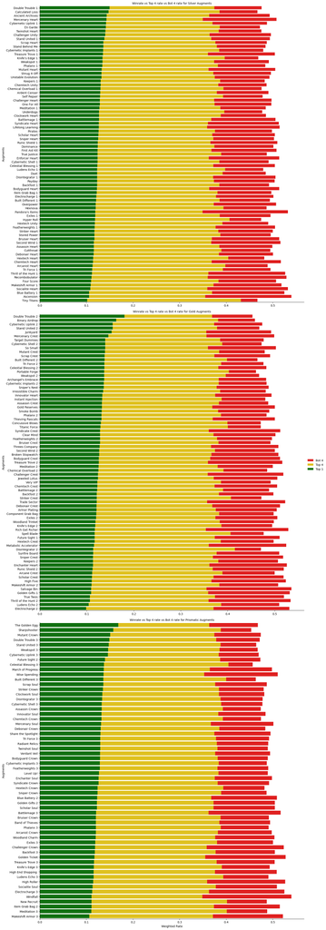

```python
augment_tiers = ["Silver", "Gold", "Prismatic"]

# Use seaborn's FacetGrid function to create separate plots grouped together by the augment's tier
g = sns.FacetGrid(augment_df, col="tier", col_order=augment_tiers,
    height=15, col_wrap=1, sharex=False, sharey=False)

# Map each plot to a barplot with the weighted win rate as the x value and the y value as the
# augments to create horizonal bar plots that are more readable
g.map(sns.barplot, 'weighted_bot4', 'augment', color='r', label='Bot 4').map(sns.barplot,
'weighted_top4', 'augment', color='gold', label='Top 4').map(sns.barplot,
'weighted_winrate', 'augment', color='g', label='Top 1')

# Set the axis labels
g.set_axis_labels("Weighted Rate", "Augments")

# Dynamically populate the title for each plot based on the augment tiers.
g.set_titles(col_template='Winrate vs Top 4 rate vs Bot 4 rate for {col_name} Augments')
g.add_legend()

# Display the plot
plt.show()
```

From the 3 separate bar graphs, we can view how certain Augments performed when utilized by the top players in TFT. We decided to sort the graphs in descending order for Winrate since that is what matters for the purpose of this tutorial. But we can still see how the Augments perform in terms of placing top 4 (places 2, 3, 4) and placing bottom 4 (places 5, 6, 7, 8).

For Augments in the Silver Tier, we can see that "Double Trouble 1" and "Calculated Loss" are the two Augments that have the highest percentage of winning a game.

For Augments in the Gold Tier, "Double Trouble 2" has a much higher winrate in comparison to the other augments.

For Augments in the Prismatic Tier, "The Golden Egg" has a much higher winrate.

For the traits data, we essentially performed the same actions that we performed for the augments data and utilized the same functions. However, traits consist of extraneous data that won't be needed for our visualization (num_units, style, tier_total). Additionally, some traits have the same name but is in a different tier. To ensure that all traits are unique, we concatenated the name of each trait with their current tier.

**Side Node:** Although removing the extraneous data may seem like a cleaning procedure, it is in fact not. The reason for that is because the **explode()** will produce rows that have unique values for traits, but will produce rows with duplicate values for all the other columns. This will heavily skew our results and should be an action that is performed specifically for the traits dataframe. It's a cleaning procedure that isn't applicable for all other dataframes.

Some players ended up with no tiers at the end of the match. To account for that, we replaced them with a recognizable missing value (**np.nan**) and dropped the rows that contained missing traits from the dataframe. For the remaining traits, the API mislabeled most of them, so we manually mapped the traits with their respective in-game names. Lastly, some traits weren't activated which would skew our results so those were manually excluded from the dataframe during our renaming.

**New functions used:**

- df.dropna(subset): Drop the row that has missing values in the specified column (subset)
- dict.get(key): Returns the value of the item with the specified key

```python
# Separate the array of traits into their own rows in the dataframe
trait_df = df.explode("traits")

# Remove unncessary values such as num_units and tier_total. Create a unique trait name by concatenating
# the name of the trait with trait's current level (tier_current). If the current player doesn't have
# traits, then designate it as a missing value.
trait_df["traits"] = trait_df["traits"].apply(lambda x: (x.get('name') + str(x.get('tier_current'))) \
if type(x) is dict else np.nan)

# Drop all rows that have missing values in the traits column
trait_df = trait_df.dropna(subset=['traits'])

# Rename the traits that the API mislabeled compared to the in-game version
# Traits with parentheses and a number indicate the requirement in activating that specific trait
# For example, Innovator (7) means 7 Units with the Innovator Trait must be in the team
trait_df['traits'] = trait_df['traits'].map(traitDictionary)

# Map specific columns to their designated aggregate function. We need the total number of
# wins, losses, and games.
aggregate_funcs = {'wins': 'sum', 'top_4': 'sum', 'losses': 'sum', 'games': 'count'}

# Generate the unweighted rates for the traits.
trait_df = data_vs_rate(trait_df, 'traits', aggregate_funcs)

# Generate the weighted rates for the traits.
trait_df = add_weighted_rate(trait_df)

# Sort the weighted win rate for the traits in descending order so that the highest win rate is at
# the top of the plot.
trait_df = trait_df.sort_values('weighted_winrate', ascending=False)

# Display the dataframe.
trait_df
```

| traits | weighted_winrate | weighted_top4 | weighted_bot4 | winrate | top4_rate | bot4_rate | wins | top_4 | losses | games |
| --- | --- | --- | --- | --- | --- | --- | --- | --- | --- | --- |
| Transformer (1) | 0.190015 | 0.429328 | 0.380657 | 0.204096 | 0.439919 | 0.355984 | 1724 | 3716 | 3007 | 8447 |
| Mastermind (1) | 0.189935 | 0.449710 | 0.360355 | 0.200865 | 0.462948 | 0.336187 | 2182 | 5029 | 3652 | 10863 |
| Glutton (1) | 0.188477 | 0.399661 | 0.411862 | 0.210516 | 0.401650 | 0.387833 | 1097 | 2093 | 2021 | 5211 |
| Scrap (4) | 0.170740 | 0.399771 | 0.429489 | 0.194118 | 0.403460 | 0.402422 | 561 | 1166 | 1163 | 2890 |
| Innovator (7) | 0.168175 | 0.410427 | 0.421397 | 0.265176 | 0.472843 | 0.261981 | 166 | 296 | 164 | 626 |
| ... | ... | ... | ... | ... | ... | ... | ... | ... | ... | ... |
| Bruiser (4) | 0.121906 | 0.368601 | 0.509493 | 0.102990 | 0.346723 | 0.550287 | 341 | 1148 | 1822 | 3311 |
| Arcanist (4) | 0.120328 | 0.373053 | 0.506619 | 0.083744 | 0.339901 | 0.576355 | 153 | 621 | 1053 | 1827 |
| Yordle (3) | 0.117884 | 0.358643 | 0.523472 | 0.080986 | 0.308853 | 0.610161 | 161 | 614 | 1213 | 1988 |
| Striker (2) | 0.116851 | 0.388119 | 0.495031 | 0.101729 | 0.384065 | 0.514206 | 512 | 1933 | 2588 | 5033 |
| Hextech (6) | 0.116201 | 0.400665 | 0.483134 | 0.071387 | 0.408175 | 0.520438 | 124 | 709 | 904 | 1737 |

79 rows × 10 columns

Unlike the augments data, the traits table will be plotted in a single bar plot since it doesn't have as many unique values as the augments data. Just like the augments data, to account for the different rates, we created a plot that has overlapping bar plots.

**New functions used:**

- plt.subplots(figsize): Creates a plot with the specified size
- sns.barplot(): Plots a barplot

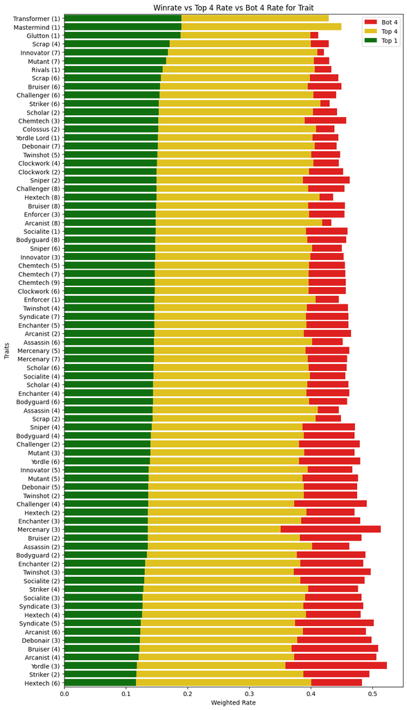

```python
# Set the size of the plot.
f, ax = plt.subplots(figsize=(10, 20))

# Create horizontal bar plots with x value being the weighted rate and the y value being the
# trait.
sns.barplot(x="weighted_bot4", y=trait_df.index, data=trait_df, ax=ax,
            label="Bot 4", color="r", order = trait_df.index)
sns.barplot(x="weighted_top4", y=trait_df.index, data=trait_df, ax=ax,
            label="Top 4", color="gold", order = trait_df.index)
sns.barplot(x="weighted_winrate", y=trait_df.index, data=trait_df, ax=ax,
            label="Top 1", color="g", order = trait_df.index)

# Set the axis labels and the title.
plt.title("Winrate vs Top 4 Rate vs Bot 4 Rate for Trait")
plt.xlabel("Weighted Rate")
plt.ylabel("Traits")
plt.legend()

# Display the plot.
plt.show()
```

Similar to the Augment's bar graph, we sort by winrate for the Traits bargraph as well.

We can see that the traits "Mastermind", "Transformer", and "Glutton" performs the best out of all of the Traits.

For "Transformer" and "Mastermind", we can see that the statistic for "Bottom 4" (in red) is missing. This does not mean that these traits have never lost, it's just that these traits perform so well that their "Winrate" and "Top 4 rate" is much higher then their "Bottom 4 rate".

Most of the actions performed to find the weighted win rate for each unit was done similarly to the augments data and traits data.

Each unit has a specific price designated by its cost (value of the rarity + 1). To keep track of the cost of each unit, we extracted the value from the JSON object (dictionary) and placed it in its own column (series). Each unit is represented as a JSON object, but we don't need them to be represented that way. So we extracted the names of each unit and replaced the JSON object with the unit's name (character_id).

In the final dataframe, the dataframe includes another column titled cost (the cost of each unit). Additionally, to help with plotting, we placed the index (unit names) in their own column in the dataframe.

```python
# Separate the units into their own rows in the dataframe
unit_df = df.explode("units")

# Each unit has a specific cost to purchase, so extract the cost from the JSON object (Dictionary) and
# place it in its own column. The cost is based on the rarity + 1.
unit_df["cost"] = unit_df["units"].apply(lambda x: x.get('rarity') + 1 if type(x) is dict else x)

# We only want the name of the unit and not the entire JSON object, so extract the name from the
# dictionary and replace the JSON object with the unit name (character_id).
unit_df["units"] = unit_df["units"].apply(lambda x: x.get('character_id') if type(x) is dict else x)

# Map specific columns to their designated aggregate function. We need the total number of
# wins, losses, games, and the cost of each unit.
unit_aggregate_functions = {'wins': 'sum', 'top_4': 'sum', 'losses': 'sum', 'games': 'count', 'cost': 'max'}

# Generate the unweighted rate for each unit.
unit_df = data_vs_rate(unit_df, 'units', unit_aggregate_functions)

# Generate the weighted rate for each unit.
unit_df = add_weighted_rate(unit_df)

# Place the unit names in their own column to help with plotting.
unit_df.insert(0, 'unit', unit_df.index)

# To organize the data, we decided to place the names of the units in the front and the cost of each
# unit after the unit's name.
unit_df.insert(1, 'cost', unit_df.pop('cost'))

# Sort the weighted win rate for the units in descending order so the highest win rate is at the top.
unit_df = unit_df.sort_values('weighted_winrate', ascending=False)

# Display the unit.
unit_df.head()
```

| units | unit | cost | weighted_winrate | weighted_top4 | weighted_bot4 | winrate | top4_rate | bot4_rate | wins | top_4 | losses | games |
| --- | --- | --- | --- | --- | --- | --- | --- | --- | --- | --- | --- | --- |
| Jinx | Jinx | 5.0 | 0.181966 | 0.416650 | 0.401384 | 0.211678 | 0.436318 | 0.352004 | 1780 | 3669 | 2960 | 8409 |
| Silco | Silco | 5.0 | 0.179358 | 0.438465 | 0.382178 | 0.200875 | 0.464120 | 0.335005 | 2203 | 5090 | 3674 | 10967 |
| Jayce | Jayce | 5.0 | 0.178549 | 0.418803 | 0.402648 | 0.205546 | 0.439408 | 0.355045 | 1764 | 3771 | 3047 | 8582 |
| TahmKench | TahmKench | 5.0 | 0.173091 | 0.393917 | 0.432992 | 0.211209 | 0.402295 | 0.386496 | 1123 | 2139 | 2055 | 5317 |
| Kaisa | Kaisa | 5.0 | 0.169087 | 0.407056 | 0.423858 | 0.208578 | 0.431962 | 0.359460 | 958 | 1984 | 1651 | 4593 |

Similar to the augments data, we need to make the data more manageable and ensure that the data is reasonable (it makes sense). So we split the data into separate groups based on the cost of the unit. Just like the augments data, it's easier to compare two different variables when they are grouped together by a commonality.

Similar to what we did for the previous dataframes, we created a plot that had overlapping bar plots to account for the three different rates (win, top 4, bottom 4).

[figure not shown]

```python
# Create separate plots for each cost using seaborn's FacetGrid function
g = sns.FacetGrid(unit_df, col="cost", col_order=[1,2,3,4,5], height=15, col_wrap=1, sharex=False, sharey=False, palette=palette_cost)

# Map each plot to a barplot with the weighted win rate as the x value and the y value as the
# augments to create horizonal bar plots that are more readable
g.map(sns.barplot, 'weighted_bot4', 'unit', color='r', label='Bot 4').map(sns.barplot,
'weighted_top4', 'unit', color='gold', label='Top 4').map(sns.barplot,
'weighted_winrate', 'unit', color='g', label='Top 1')

# Set the axis labels
g.set_axis_labels("Weighted Rate", "Units")

# Dynamically create the title for each plot based on the cost of the units
g.set_titles(col_template='Winrate vs Top 4 rate vs Bot 4 rate for {col_name} Cost Units')
g.add_legend()

# Display the plot
plt.show()
```

For the 1-Cost Units, the best performing Units are Ezreal and Kassadin.

For the 2-Cost Units, the best performing Units are Warwick and Quinn.

For the 3-Cost Units, the best performing Units are Tryndamere and Ekko.

For the 4-Cost Units, the best performing Units are Orianna and Jhin.

For the 5-Cost Units, the best performing Units are Jinx, Silco, and Jayce.

Similar to the Trait bar graph, Units such as Jinx, Silco, Jayce, and Viktor perform so well that their "Bottom 4 rate" is not visible.

Similar to the previous dataframes, we used similar functions and performed similar actions to generate the weighted rate for each item.

However, we needed to remove Components from the dataframe. This is because components are essentially useless since they are mainly used to create craftable Items and provide little benefit to a player's chances of winning on their own.

Then, we needed to split the remaining items into either "Craftable" and "Uncraftable" Items since items listed under "Uncraftable" appears comparatively less (due to being restricted behind Augments) and may skew the data.

In the case of Items in the dataframe, they are stored in each unit as an array because each unit are given a specified number of items. But we will only be constructing our data with units that have three items. This is because units with three items are considered more significant than units with less than 3 items. Units with less than 3 items are considered filler units which have less of an effect on the win rate.

**New functions used:**

- df.isin(values): Determines whether each element in the DataFrame is contained in values.

```python
# Separate the items into components and uncraftable items
components = ["B.F. Sword", "Chain Vest", "Giant's Belt", "Needlessly Large Rod", "Negatron Cloak", "Recurve Bow", "Sparring Gloves", "Spatula", "Tear of the Goddess"]
uncraftable = ["Anima Visage", "Death's Defiance", "Eternal Winter", "Infinity Force", "Manazane", "Obsidian Cleaver", "Randuin's Sanctum", "Rocket-Propelled Fist", "Gold Collector", "Zhonya's Paradox", "Bodyguard Emblem", "Clockwork Emblem", "Mercenary Emblem", "Socialite Emblem", "Enforcer Emblem", "Scrap Emblem", "Bruiser Emblem", "Innovator Emblem", "Sniper Emblem", "Scholar Emblem", "Luminous Deathblade", "Demonslayer", "Hextech Lifeblade", "Spear of Hirana", "Brink of Dawn", "Blessed Bloodthirster", "Zeke's Harmony", "Zenith Edge", "Rapid Lightcannon", "Guinsoo's Reckoning", "Statikk's Favor", "Titan's Vow", "Runaan's Tempest", "Zz'Rots Invitation", "Eternal Whisper", "Rabadon's Ascended Deathcap", "Urf-Angel's Staff", "Locket of Targon Prime", "Covalent Spark", "More More-ellonomicon", "Glamorous Gauntlet", "Blue Blessing", "Frozen Heart Of Gold", "Chalice of Charity", "Radiant Redemption", "Fist of Fairness", "Rosethorn Vest", "Dvarapala Stoneplate", "Sunlight Cape", "Shroud of Reverence", "Dragon's Will", "Mistral", "Quickestsilver", "Warmog's Pride", "Banshee's Silence", "Rascal's Gloves" ]

# Separate the unit array into separate rows for each unit since each unit has an array of items
item_df = df.explode("units")

# Extract the array of items from each unit
item_df["items"] = item_df["units"].apply(lambda x: x.get('items') if type(x) is dict and \
len(x.get('items')) == 3 else np.nan)

# Drop the missing values in the items column
item_df = item_df.dropna(subset=['items'])

# Separate the item array into separate rows in the dataframe
item_df = item_df.explode('items')

# Map specific columns to their designated aggregate function. We need the total number of
# wins, top 4, losses, and games.
item_aggregate_functions = {'wins': 'sum', 'top_4': 'sum', 'losses': 'sum', 'games': 'count'}

# Generate the unweighted win rate for each item
item_df = data_vs_rate(item_df, 'items', item_aggregate_functions)

# Generate the weighted win rate for each item
item_df = add_weighted_rate(item_df)

# To help with plotting, the index (item names) are placed in their own column
item_df.insert(0, 'itemName', item_df.index)

# Remove items that are components
item_df = item_df[~item_df['itemName'].isin(components)]

# Put the types of each item into their own column
item_df.insert(1, 'type', np.where(item_df['itemName'].isin(uncraftable), 'Uncraftable', 'Craftable'))

# Sort the weighted win rate for each item in descending order to have the highest win rate at the top
item_df = item_df.sort_values('weighted_winrate', ascending=False)

# Display the plot
item_df
```

| items | itemName | type | weighted_winrate | weighted_top4 | weighted_bot4 | winrate | top4_rate | bot4_rate | wins | top_4 | losses | games |
| --- | --- | --- | --- | --- | --- | --- | --- | --- | --- | --- | --- | --- |
| Zeke's Herald | Zeke's Herald | Craftable | 0.192526 | 0.469256 | 0.338218 | 0.203287 | 0.483387 | 0.313326 | 1138 | 2706 | 1754 | 5598 |
| Edge of Night | Edge of Night | Craftable | 0.192464 | 0.434175 | 0.373360 | 0.205824 | 0.434319 | 0.359858 | 926 | 1954 | 1619 | 4499 |
| Mutant Emblem | Mutant Emblem | Craftable | 0.188669 | 0.434285 | 0.377046 | 0.244831 | 0.435256 | 0.319913 | 225 | 400 | 294 | 919 |
| Shroud of Stillness | Shroud of Stillness | Craftable | 0.187817 | 0.442880 | 0.369302 | 0.207797 | 0.450965 | 0.341238 | 517 | 1122 | 849 | 2488 |
| Banshee's Claw | Banshee's Claw | Craftable | 0.186956 | 0.460078 | 0.352965 | 0.203901 | 0.480851 | 0.315248 | 575 | 1356 | 889 | 2820 |
| ... | ... | ... | ... | ... | ... | ... | ... | ... | ... | ... | ... | ... |
| Thief's Gloves | Thief's Gloves | Craftable | 0.153161 | 0.419383 | 0.427456 | 0.148789 | 0.414281 | 0.436930 | 946 | 2634 | 2778 | 6358 |
| Hextech Gunblade | Hextech Gunblade | Craftable | 0.153091 | 0.413094 | 0.433816 | 0.149723 | 0.407492 | 0.442785 | 1243 | 3383 | 3676 | 8302 |
| Blue Buff | Blue Buff | Craftable | 0.148995 | 0.408906 | 0.442100 | 0.144996 | 0.402887 | 0.452117 | 1346 | 3740 | 4197 | 9283 |
| Infinity Edge | Infinity Edge | Craftable | 0.147860 | 0.409280 | 0.442860 | 0.145182 | 0.405564 | 0.449254 | 2150 | 6006 | 6653 | 14809 |
| Guinsoo's Rageblade | Guinsoo's Rageblade | Craftable | 0.147703 | 0.418015 | 0.434282 | 0.144259 | 0.414960 | 0.440782 | 1676 | 4821 | 5121 | 11618 |

102 rows × 12 columns

To help with plotting each item in two separate groups (Craftable and Uncraftable), the index (item names) need to be placed into a separate column (series).

The data is then plotted as separate bar plots grouped by the item type.

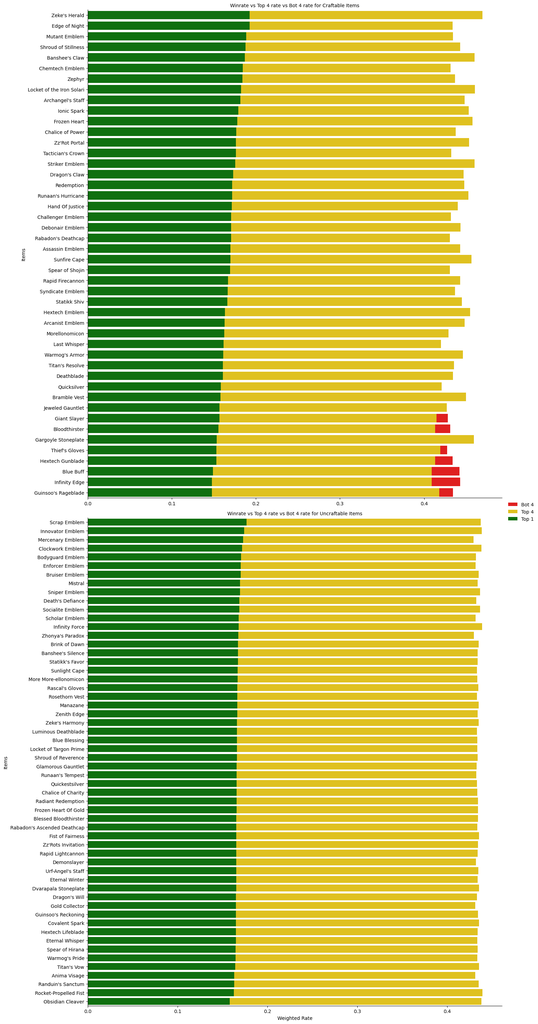

```python
# Create separate plots for craftable and uncraftable items using seaborn's FacetGrid function
g = sns.FacetGrid(item_df, col="type",  height=15, col_wrap=1, sharex=False, sharey=False)

# Map each plot to a barplot with the weighted win rate as the x value and the y value as the
# item to create horizonal bar plots that are more readable
g.map(sns.barplot, 'weighted_bot4', 'itemName', color='r', label='Bot 4').map(sns.barplot,
'weighted_top4', 'itemName', color='gold', label='Top 4').map(sns.barplot, 'weighted_winrate', 'itemName', color='g', label='Top 1')

# Set the axis labels
g.set_axis_labels("Weighted Rate", "Items")

# Dynamically create the title for each plot based on whether the items are Craftable or Uncraftable
g.set_titles(col_template='Winrate vs Top 4 rate vs Bot 4 rate for {col_name} Items')
g.add_legend()

# Display the plot
plt.show()
```

The best performing Craftable items are Zeke's Herald and Edge of Night.

The best performing Uncraftable items is Scrap Emblem.

As with the other bar graphs, the "Bottom 4 rate" is not visible for certain Items. The main difference for these sets of bar graphs is that this applies to a large majority of the Items. This can be interpretted as players utilizing Items have a much larger influence on a player's ability to Win & place top 4 compared to Augments/Units/Traits.

# Prediction Modeling

In order to predict the best strategy needed in order to *win* a game of TFT, we opted to use a Decision Tree as our predictive model. The main reason for choosing a Decision Tree stems from the fact that we have attribute-value pairs for Units/Items/Traits/Augments and the end result of the model is discrete (i.e. determine a win/top 4/ bottom 4).

A decision tree is also easier to intrepet for our data in comparison to other models. What we are mainly focusing on is determining a path that an individual can use to achieve the highest placement. The decision tree is the best way to illustrate that motive and represent the result. For instance, one can easily determine a path by looking at a tree. Whereas, pure data is a lot harder to interpret and requires a deeper analysis to truly determine the optimal path. This is especially the case in our situation because we need to analyze the consequences of each decision that we make. For example, whether taking a certain item leads to a more optimal path than taking another item (Zeke's Herald vs Edge of Night).

Since our data is heavily categorical, we need to define a few functions that could help us with plugging our data into a learning algorithm. We can't simply use the names for a unit, item, etc. We need to first encode these values numerically and so we chose to utilize one hot encoding.

Functions to convert the list of JSON objects into a Set of Strings. We chose to use a set because we don't want to have duplicate values in our encoded data.

```python
# Convert a list of JSON objects into individual traits
# Input: Array (JSON)
# Output: Set (Strings)
def get_trait_names(arr):
    # Iterates through each trait JSON object and extracts the trait name + tier into a Set
    # Avoids extracting traits that are unactivated (tier_current = 0)
    return {trait.get('name') + str(trait.get('tier_current')) for trait in arr \
    if trait.get('tier_current') != 0}

# Convert a list of JSON objects into individual units
# Input: Array (JSON)
# Output: Set (Strings)
def get_unit_names(arr):
    # Iterates through each unit JSON object and extracts the unit name into a Set
    return {unit.get('character_id') for unit in arr}

# Convert a list of JSON objects into individual items
# Input: Array (JSON)
# Output: Set (Strings)
def get_item_names(arr):
    # Iterates through each unit JSON object and extracts the item name into a Set
    return {item for unit in arr for item in unit.get('items')}
```

Function that we use to build binary vector for the specified attribute (column) that utilizes one hot encoding.

Input:

- frame (DataFrame): The target DataFrame that we want to one hot encode
- attribute (String): The specific attribute that needs to be one hot encoded (augment, traits, etc.)
- placement (Series): The placement of each player

Output: A Pandas DataFrame

**New functions used:**

- pd.get_dummies(): Convert categorical variable into dummy/indicator variables.

```python
def build_df_for_encoding(frame, attribute, placement):
    # One hot encode augments
    if attribute == 'augments':
        # Augments should not have a prefix nor a prefix separator since we will make a separate
        # decision tree to augments
        frame = pd.get_dummies(frame, columns=[attribute], prefix='', prefix_sep='')
    else:
        # The other attributes besides augments should have a prefix and separator because we need to
        # distinguish between units, items, and traits in our decision tree
        frame = pd.get_dummies(frame, columns=[attribute])

    # Group the rows by the player to make a one dimensional binary vector that indicates whether
    # a player has an attribute (1) or does not have an attribute (0)
    frame = frame.groupby(frame.index)[frame.columns[5:]].sum()

    # Place the placement of each player in the first column
    frame.insert(0, 'placement', placement)

    # Return the DataFrame
    return frame
```

Without doing anything to our data, it will be difficult for us to plug it into a learning algorithm. This is because our data is mostly categorical. To address this issue, we opted to use one hot encoding to create a binary vector for our data. So for each player, a 1 on a column indicates whether they have an item, unit, augment, and/or a trait. Otherwise there will be a 0. To avoid possibly affecting our original data, we made a copy of our original dataframe.

Another problem with our data is that units, items, and traits consist of JSON objects. It will be difficult and unreasonable for us to perform one hot encoding on JSON objects. Therefore, we converted the JSON objects into Strings by extracting values that we will consider from the JSON object.

Simply leaving our data with 8 possible placements for a player will make our decision tree extremely inaccurate. To improve the accuracy, we encoded placements of 5, 6, 7, 8 as 3 (bottom 4), placements of 2, 3, 4 as 2 (top 4), and a placement of 1 as 1 (win). In TFT, placing in the bottom 4 causes you to lose ELO (ranking points), placing the top 4 does not lose ELO but you're not truly winning, and placing number 1 means that you truly won the game.

To properly one hot encode each value, we used the function **explode()** for each attribute. As I mentioned before, explode produces rows with unique values in the specified column, but duplicate values for all other columns. Therefore, we used explode() for each attribute and one hot encoded them separately. For items, we had one extra step since we had to remove all items that are components because their significance in helping a player win is significantly less than a craftable or uncraftable item.

After careful consideration, we decided to split the attributes into two different decision trees. One would consist of units, traits, and items. The other will be a decision tree for augments. The reason why we chose to do this is that there is a relationship between units, traits, and items. For instance, each unit has a certain number of items, and traits provide stronger benefits when you have a higher number of units that have that specific trait. On the other hand, the effect of augments are not entirely dependent on units/traits/items as they provide their own influence on how a player can win a game.

To merge the attributes, we utilized the **merge()** function and specified the join as an inner join. This is to ensure that there aren't any missing values.

**New functions used:**

- df.copy(deep): Make a copy of this object’s indices and data, true is default argument 'deep' so a deep copy is made

```python
# Create a copy of our cleaned DataFrame
encoding_prep_df = df.copy()

# For each column that isn't a Set of Strings, convert the list of JSON objects into a Set of Strings
encoding_prep_df['traits'] = encoding_prep_df['traits'].apply(lambda x: get_trait_names(x))
encoding_prep_df['items'] = encoding_prep_df['units'].apply(lambda x: get_item_names(x))
encoding_prep_df['units'] = encoding_prep_df['units'].apply(lambda x: get_unit_names(x))

# Placements of 5, 6, 7, 8 are encoded as 3 (bottom 4), placements of 2, 3, 4 are encoded as 2 (top 4),
# and a placement of 1 is encoded as 1 (win)
placement = encoding_prep_df['placement'].apply(lambda x: 3 if x > 4 else (2 if x > 1 else 1))

# One hot encode traits
encoded_traits = encoding_prep_df.explode('traits')
encoded_traits = build_df_for_encoding(encoded_traits, 'traits', placement)

# One hot encode augments
encoded_augments = encoding_prep_df.explode('augments')
encoded_augments = build_df_for_encoding(encoded_augments, 'augments', placement)

# Remove items that are components
# One hot encode items
encoded_items = encoding_prep_df.explode('items')
encoded_items = encoded_items[~encoded_items['items'].isin(components)]
encoded_items = build_df_for_encoding(encoded_items, 'items', placement)

# One hot encode units
encoded_units = encoding_prep_df.explode('units')
encoded_units = build_df_for_encoding(encoded_units, 'units', placement)

# Merge the one hot encoding of traits, units, and items
# An inner join was used to ensure that we don't have missing values
encoded_attributes = pd.merge(encoded_traits, encoded_units, left_index=True, right_index=True)
encoded_attributes = pd.merge(encoded_attributes, encoded_items, left_index=True, right_index=True)

# Remove the extraneous placement columns left over from the merge
encoded_attributes.drop(axis=1, columns=['placement_x', 'placement_y'], inplace=True)

# Move the placement column into the first index (column)
encoded_attributes.insert(0, 'placement', encoded_attributes.pop('placement'))

# Display the dataframe for the one hot encoding of traits, units, and items
encoded_attributes
```

|  | placement | traits_Arcanist2 | traits_Arcanist3 | traits_Arcanist4 | traits_Assassin1 | traits_Assassin2 | traits_Assassin3 | traits_Bodyguard1 | traits_Bodyguard2 | traits_Bodyguard3 | ... | items_Urf-Angel's Staff | items_Warmog's Armor | items_Warmog's Pride | items_Zeke's Harmony | items_Zeke's Herald | items_Zenith Edge | items_Zephyr | items_Zhonya's Paradox | items_Zz'Rot Portal | items_Zz'Rots Invitation |
| --- | --- | --- | --- | --- | --- | --- | --- | --- | --- | --- | --- | --- | --- | --- | --- | --- | --- | --- | --- | --- | --- |
| 0 | 3 | 0 | 0 | 0 | 1 | 0 | 0 | 1 | 0 | 0 | ... | 0 | 0 | 0 | 0 | 1 | 0 | 0 | 0 | 0 | 0 |
| 1 | 2 | 0 | 0 | 0 | 1 | 0 | 0 | 0 | 0 | 0 | ... | 0 | 0 | 0 | 0 | 0 | 0 | 0 | 0 | 0 | 0 |
| 10 | 3 | 0 | 0 | 0 | 0 | 0 | 0 | 0 | 0 | 0 | ... | 0 | 0 | 0 | 0 | 0 | 0 | 0 | 0 | 0 | 0 |
| 100 | 3 | 0 | 0 | 0 | 0 | 0 | 0 | 1 | 0 | 0 | ... | 0 | 0 | 0 | 0 | 1 | 0 | 0 | 0 | 0 | 0 |
| 1000 | 1 | 0 | 0 | 0 | 0 | 0 | 0 | 0 | 1 | 0 | ... | 0 | 1 | 0 | 0 | 0 | 0 | 0 | 0 | 0 | 0 |
| ... | ... | ... | ... | ... | ... | ... | ... | ... | ... | ... | ... | ... | ... | ... | ... | ... | ... | ... | ... | ... | ... |
| 9995 | 3 | 0 | 0 | 0 | 0 | 0 | 0 | 0 | 0 | 0 | ... | 0 | 0 | 0 | 0 | 0 | 0 | 0 | 0 | 0 | 0 |
| 9996 | 3 | 0 | 1 | 0 | 0 | 0 | 0 | 0 | 0 | 0 | ... | 0 | 0 | 0 | 0 | 1 | 0 | 0 | 0 | 0 | 0 |
| 9997 | 3 | 0 | 0 | 0 | 0 | 0 | 0 | 1 | 0 | 0 | ... | 0 | 0 | 0 | 0 | 0 | 0 | 0 | 0 | 0 | 0 |
| 9998 | 3 | 0 | 0 | 0 | 0 | 0 | 0 | 0 | 0 | 0 | ... | 0 | 0 | 0 | 0 | 0 | 0 | 1 | 0 | 0 | 0 |
| 9999 | 2 | 1 | 0 | 0 | 0 | 0 | 0 | 0 | 0 | 0 | ... | 0 | 1 | 0 | 0 | 0 | 0 | 0 | 0 | 0 | 0 |

39964 rows × 239 columns

Before being able to produce a decision tree for units, items, and traits, we need to train the data. To ensure that we're not overfitting, we used a 80/20 split for the training and testing data respectively. We used the binary vector as the independent variable and the placement as the dependent variable since we want to determine the optimal path for winning.

**Alternatives:** Some other models that we considered were K nearest neighbors (KNN) and Random Forest. However, even though we could use KNN for indicating combinations with a distance close to ones that won, it doesn't exactly fit the type of result that we're going for. Additionally, the prediction by the model is mostly for classifying data and what we want is finding the optimal path. As for Random Forest, the result produced had a decent enough accuracy, but the end result of the tree made no sense and the model was extremely expensive. It took far too long in producing incomplete results.

Since the trees are quite large, we plotted the tree with a font size of 10 and saved it in a separate png file with a dpi of 200 so that it's readable. The feature names of the tree is the specific attribute and the class names would indicate the placement when using that path (combination).

**New functions used:**

- df.to_numpy(): Convert the DataFrame to a NumPy array.
- train_test_split(): Split arrays or matrices into random train and test subsets.
- tree.DecisionTreeClassifier(): A decision tree classifier for creating decision tree that we can fit our data into
- tree.fit(): Trains our data on the provided x and y values
- tree.plot_tree(): Plots the decision tree
- plt.savefig(): Saves the figure as an image
- tree.score(): Computes the accuracy score by default (number of predictions / all predictions)

```
Accuracy of the model: 0.5532340798198424
```

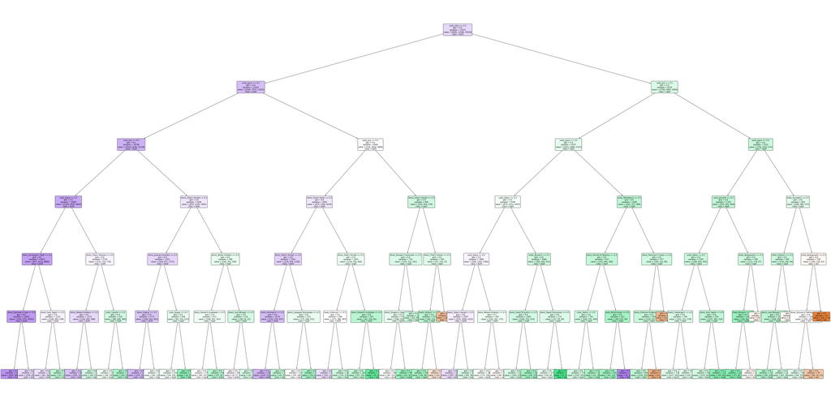

```python
# We make x be the binary vector of units, traits, and items.
# We make y b the placement of the player
X, y = encoded_attributes[encoded_attributes.columns[1:]].to_numpy(), encoded_attributes['placement']

# We split the training and testing data with a 80/20 split. Control the shuffling by setting
# random_state as 0.
X_train, X_test, y_train, y_test = train_test_split(X, y, test_size=0.20, random_state=0)

# Fit the data into the decision tree and a node will be split if this split induces a decrease
# of the impurity greater than or equal to 0.0001.
# Max depth is 5 because a higher depth is computationally expensive
DTree = tree.DecisionTreeClassifier(min_impurity_decrease=0.0001, max_depth=6, random_state=0)
DTree.fit(X_train, y_train)

# Set the size of the plot to include all nodes
fig, axe = plt.subplots(figsize=(80,40))

# Plot the tree with the unit, traits, and items' names and classify each decision with a placement
tree.plot_tree(DTree,
                feature_names = encoded_attributes.columns[1:],
                class_names=['win', 'top4', 'bot4'],
                rounded = True, proportion = False,
                precision = 1, filled = True, max_depth=6, fontsize=10)

# Save the image of the tree to file 'attributes_tree.png' in the assets folder
plt.savefig('./assets/attributes_tree', dpi=200)

# Print the accuracy of the model
print("Accuracy of the model:", DTree.score(X_test, y_test))

# Display the tree
plt.show()
```

For our decision tree, the right branch (> 0.5) indicates that the player has the specified unit, item, or trait. The left branch (<= 0.5) indicates that the player does not have the specified unit, item, or trait. The class indicates the placement of the player when traveling on the tree path.

For example:

- From the root of the decision tree, going to the right branch indicates the player has the Unit Silco on their board
- Going to the right branch again indicates that the player has the Unit Jinx on their board
- Going to the right branch again indicates that the player has the Unit Jayce on their board
- Going to the right branch again indicates that the player has the trait Socialite 1 active on their board
- Going to the right branch again indicates that the player has the trait Bodyguard 2 active on their board
- By going through this certain path on the decision tree, it is predicted that the player will win the game

**Side note:** With how small the font size is and the number of decisions, we had to save the tree in a separate file in the assets folder. To view the tree, one can either download the file or right click on the output to *open an image in a new tab*. It will require zooming in.

Similar to the attributes decision tree, the same actions were performed for the augments decision tree. Although, the min_impurity_decrease had to be decreased. The reason for that is that the data for augments is smaller and players can't have a high number of augments.

```
Accuracy of the model: 0.5065
```

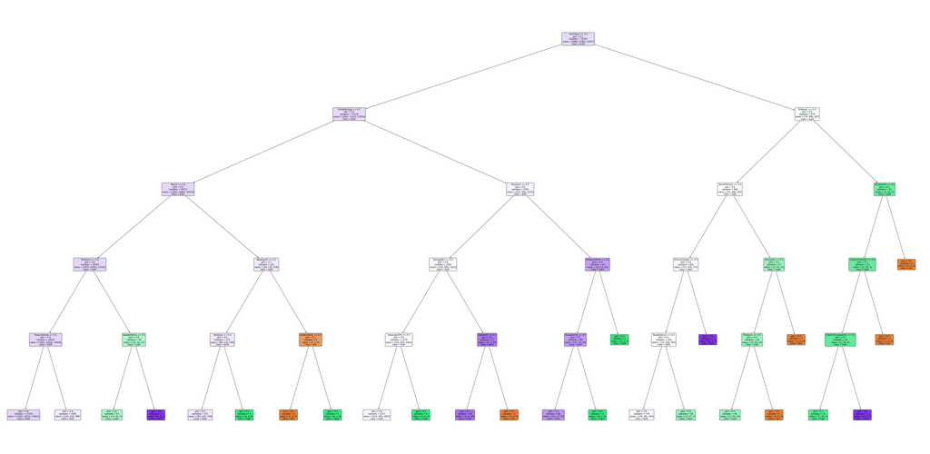

```python
# We make x be the binary vector of augments
# We make y b the placement of the player
X, y = encoded_augments[encoded_augments.columns[1:]].to_numpy(), encoded_augments['placement']

# We split the training and testing data with a 80/20 split. Control the shuffling by setting
# random_state as 0.
X_train, X_test, y_train, y_test = train_test_split(X, y, test_size=0.20, random_state=0)

# Fit the data into the decision tree and a node will be split if this split induces a decrease
# of the impurity greater than or equal to 0.00001.
DTree = tree.DecisionTreeClassifier(min_impurity_decrease=0.00001, max_depth=5)
DTree = DTree.fit(X_train, y_train)

# Set the size of the plot to include all nodes
fig, axe = plt.subplots(figsize=(80,40))

# Plot the tree with the augment names and classify each decision with a placement
tree.plot_tree(DTree,
                feature_names = encoded_augments.columns[1:],
                class_names = ['win', 'top4', 'bot4'],
                rounded = True, proportion = False,
                precision = 1, filled = True, max_depth=5, fontsize=10)

# Save the image of the tree to file 'attributes_tree.png' in the assets folder
plt.savefig('./assets/augments_tree', dpi=200)

# Print the accuracy of the model
print("Accuracy of the model:", DTree.score(X_test, y_test))

# Display the plot
plt.show()
```

Similar to the attributes tree, the right branch indicates that the player does have the augment and the left branch indicates that the player does not have the augment. Class names indicate the placement of the player.

For example:

- From the root, going to the right branch means the player has the Augment "Tiny Titans"
- Going to the right branch means the player has the Augment "Phalanx 1"
- Going to the right branch means the player has the Augment "Verdent Veil"
- By going through this path on the decision tree, it is predicted that a player will win with these choices as their 3 Augments

**Side note:** With how small the font size is and the number of decisions, we had to save the tree in a separate file in the assets folder. To view the tree, one can either download the file or right click on the output to *open an image in a new tab*. It will require zooming in.

# Insights Attained

From the data and tables we've created, we can conclude that there isn't just 1 factor that determines the placing of a player but rather the complex interaction of a wide variety of variables that decides whether a player wins. Nonetheless, the data does show that certain items, units, and augments have slightly higher winrates compared to others as well as those that have lower winrates than the others. Using this information can be helpful in determining which items, units, and augments to attain while playing as well as those to avoid in order to have a slight edge over future opponents.

On the other hand, due to the complexity of the game, fitting the data to a decision tree creates a overly complex and tall data tree with a score of ~50. However, despite the low score, the decision tree can still be utilized as a prediction model for determining the best strategy to winning in TFT. This is especially the case because some paths of the decision tree actually produced accurate results and makes practical sense as mentioned in our analysis of the tree (attributes).

The skills learned throughout this tutorial such as data collection, data tidying, and exploratory analysis, are all apart of the data pipeline. Each section focused on a variety of skills and general knowledge that had to be applied differently to accomplish a specific task and produce the desired result. Thus, you can apply these skills to any other dataset regardless of the topic.

Our last conclusion is that data science is hard and that creating an accurate predicting model is much more difficult than we first imagined when starting this project. Gathering data is tedious and tidying the data is even more tedious. But on the bright side, we became more familiar with the pipeline and understand data to a higher degree. With that said, data isn't simply numbers and letters. It's significantly more complex than that.